# Preparation

## 实验介绍

### 1.实验内容

本实验包括:

- 熟悉课程平台Jupyter实验环境
- 使用Matplotlib创建散点图

### 2.实验目标

通过实验熟悉课程平台环境，掌握Jupyter的基础操作

### 3.实验环境

- python 3.6.5
- numpy 1.13.3
- matplotlib 2.2.3

### 实验准备

点击屏幕右上方的下载实验数据模块，选择下载kNN_Dating.tgz到指定目录下，然后再依次选择点击上方的File->Open->Upload,上传刚才下载的数据集压缩包，再使用如下命令解压：

```python
!tar -zxvf kNN_Dating.tgz
```

```
kNN_Dating/
kNN_Dating/datingTestSet.txt
```

```python
import numpy as np
import matplotlib.lines as mlines
import matplotlib.pyplot as plt
```

## 实验步骤：【绘制散点图】- 概述

### 数据介绍

海伦收集约会数据已经有了一段时间，她把这些数据存放在文本文件datingTestSet.txt中，每个样本数据占据一行，总共有1000行。

海伦收集的样本数据主要包含以下3种特征：

- 每年获得的飞行常客里程数 (Number of frequent flyer miles earned per year)
- 玩视频游戏所消耗时间百分比 (Percentage of time spent playing video games)
- 每周消费的冰淇淋公升数 (Liters of ice cream consumed per week)

数据标签包含以下3类：

- 不喜欢的人 (didntLike)
- 魅力一般的人 (smallDoses)
- 极具魅力的人 (largeDoses)

### 数据示例

[figure not shown]

## 实验步骤：【绘制散点图】- 数据读取与处理

将数据分类两部分，即特征矩阵和对应的分类标签向量。定义名为file2matrix的函数，以此来处理输入格式问题。编写代码如下：

```python
def file2matrix(filename):
    """
    函数说明：加载数据集
    parameters:
        fileName - 文件名
    return:
        featureMat - 特征矩阵
        classLabelVector - 类别标签向量(didntLike - 0, smallDoses - 1, largeDoses - 2)
    """
    # 打开文件
    fr = open(filename)
    # 读取文件所有内容
    arrayOLines = fr.readlines()
    # 得到文件行数
    numberOfLines = len(arrayOLines)
    # 返回的NumPy矩阵,解析完成的数据:numberOfLines行,3列
    returnMat = np.zeros((numberOfLines,3))
    print(returnMat)
    # 返回的分类标签向量
    classLabelVector = []
    # 行的索引值
    index = 0
    for line in arrayOLines:
        # s.strip(rm)，当rm空时,默认删除空白符(包括'\n','\r','\t',' ')
        line = line.strip()
        # 使用s.split(str="",num=string,cout(str))将字符串根据'\t'分隔符进行切片。
        listFormLine = line.split('\t')
        # 将数据前三列提取出来,存放到returnMat的NumPy矩阵中,也就是特征矩阵
        returnMat[index,:] = listFormLine[0:3]
        # 根据文本中标记的喜欢的程度进行分类,1代表不喜欢,2代表魅力一般,3代表极具魅力
        if listFormLine[-1] == 'didntLike':
            classLabelVector.append(1)
        elif listFormLine[-1] == 'smallDoses':
            classLabelVector.append(2)
        elif listFormLine[-1] == 'largeDoses':
            classLabelVector.append(3)
        index += 1

    return returnMat,classLabelVector
```

## 实验步骤：【绘制散点图】- 分析数据数据可视化

### 预期可视化结果

[figure not shown]

```python
def showdatas(datingDataMat, datingLabels):
    """
    函数说明：绘制散点图
    parameters:
        datingDataMat - 特征矩阵
        datingLabels - 类别标签向量(didntLike - 0, smallDoses - 1, largeDoses - 2)
    """
    # 设置标签
    labels = ['didntLike', 'smallDoses', 'largeDoses']
    features = ['Number of frequent flyer miles earned per year',
              'Percentage of time spent playing video games',
              'Liters of ice cream consumed per week']
    fig, ax = plt.subplots(3, figsize = (12, 12))
    # 设置颜色
    colornames = ['black', 'orange', 'red']
    # 通过dataLabels来选择不同颜色
    colorv = [colornames[x-1] for x in datingLabels]
    # 绘制图片
    scatter0 = ax[0].scatter(x=datingDataMat[:,0], y=datingDataMat[:,1], c=colorv, s=15, alpha=0.5, label=labels)
    ax[0].set_xlabel(features[0])
    ax[0].set_ylabel(features[1])
    ax[1].scatter(x=datingDataMat[:,0], y=datingDataMat[:,2], c=colorv, s=15, alpha=0.5, label=labels)
    ax[1].set_xlabel(features[0])
    ax[1].set_ylabel(features[2])
    ax[2].scatter(x=datingDataMat[:,1], y=datingDataMat[:,2], c=colorv, s=15, alpha=0.5, label=labels)
    ax[2].set_xlabel(features[1])
    ax[2].set_ylabel(features[2])
    # 设置图例
    didntLike = mlines.Line2D([], [], color='black', marker='.',
                              markersize=6, label='didntLike')
    smallDoses = mlines.Line2D([], [], color='orange', marker='.',
                               markersize=6, label='smallDoses')
    largeDoses = mlines.Line2D([], [], color='red', marker='.',
                               markersize=6, label='largeDoses')
    # 添加图例
    ax[0].legend(handles=[didntLike, smallDoses, largeDoses])
    ax[1].legend(handles=[didntLike, smallDoses, largeDoses], loc='lower right')
    ax[2].legend(handles=[didntLike, smallDoses, largeDoses], loc='upper right')
    plt.show()
```

```
[[ 0.  0.  0.]
 [ 0.  0.  0.]
 [ 0.  0.  0.]
 ...,
 [ 0.  0.  0.]
 [ 0.  0.  0.]
 [ 0.  0.  0.]]
```

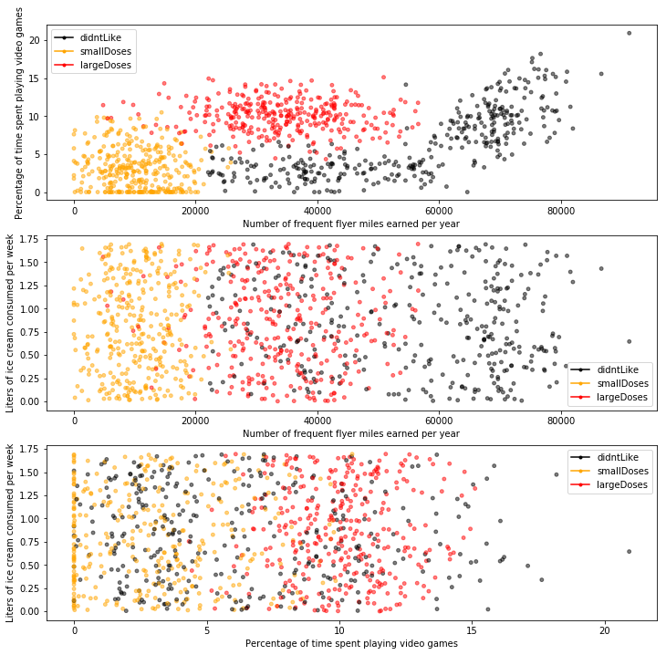

```python
if __name__ == '__main__':
    filename = "kNN_Dating/datingTestSet.txt"
    datingDataMat, datingLabels = file2matrix(filename)
    showdatas(datingDataMat, datingLabels)
```